# UCI Machine Learning Repository Dataset - AIDS Clinical Trials Group Study 175

The UCI Machine Learning Repository is a well-known resource for accessing a wide range of datasets used for machine learning research and practice. One such dataset is the AIDS Clinical Trials Group Study dataset, which can be used to build and evaluate predictive models.

In our library, you can easily fetch this dataset using the ucimlrepo package. If you haven't installed it yet, you can do so by running `pip install ucimlrepo`.

## Model Tuner Library Instructions

This notebook provides a guide on how to install and use the `model_tuner` library in a notebook environment like Google Colab.

## Model Tuner Description

The `model_tuner` library is designed to streamline the process of hyperparameter tuning and model optimization for machine learning algorithms. It provides an easy-to-use interface for defining, tuning, and evaluating models.

#### Key Features

**Automatic Hyperparameter Tuning**

The library can automatically tune hyperparameters for a variety of machine learning models using advanced optimization techniques.

**Cross-Validation**

Integrated cross-validation ensures that the models are evaluated robustly, preventing overfitting.

### Documentation

For detailed documentation and advanced usage of the model_tuner library, please refer to the [model_tuner documentation](https://uclamii.github.io/model_tuner/).

By following these steps, you should be able to install and use the `model_tuner` library effectively in your notebook environment. If you encounter any issues or have further questions, feel free to reach out for support.

## Installation

To install the `model_tuner` library, use the following command:

```python
! pip install model_tuner
```

[output not shown]

## Importing the Library

After installation, you can import the necessary components from the model_tuner library as shown below:

```python
import model_tuner # import model_tuner to show version info.
from model_tuner import Model # Model class from model_tuner lib.
```

### Checking the Version

To ensure that the model_tuner library is installed correctly, you can check its version:

```python
print(help(model_tuner))
```

```
Help on package model_tuner:

NAME
    model_tuner

DESCRIPTION
    $$$$$$$$$$$$$$$$$$$$$$$$$$$$$$$$$$$$$$$$$$$$$$$$$$$$$$$$$$$$$$$$$$$
    $      __  __           _      _   _____                          $
    $     |  \/  | ___   __| | ___| | |_   _|   _ _ __   ___ _ __     $
    $     | |\/| |/ _ \ / _` |/ _ \ |   | || | | | '_ \ / _ \ '__|    $
    $     | |  | | (_) | (_| |  __/ |   | || |_| | | | |  __/ |       $
    $     |_|  |_|\___/ \__,_|\___|_|   |_| \__,_|_| |_|\___|_|       $
    $                                                                 $
    $$$$$$$$$$$$$$$$$$$$$$$$$$$$$$$$$$$$$$$$$$$$$$$$$$$$$$$$$$$$$$$$$$$

    The `model_tuner` library is a versatile and powerful tool designed to
    facilitate the training, evaluation, and tuning of machine learning models.
    It supports various functionalities such as handling imbalanced data, applying
    different scaling and imputation techniques, calibrating models, and conducting
    cross-validation. This library is particularly useful for model selection,
    hyperparameter tuning, and ensuring optimal performance across different metrics.

    Version: 0.0.19a

PACKAGE CONTENTS
    bootstrapper
    main
    model_tuner_utils
    pickleObjects

DATA
    __email__ = 'lshpaner@ucla.edu; alafunnell@gmail.com; pp89@ucla.edu'

VERSION
    0.0.19a

AUTHOR
    Arthur Funnell, Leonid Shpaner, Panayiotis Petousis

FILE
    /usr/local/lib/python3.10/dist-packages/model_tuner/__init__.py


None
```

## AIDS Clinical Trials Group Study 175 Dataset

The AIDS Clinical Trials Group Study 175 Dataset is a healthcare dataset that contains statistical and categorical information about patients who have been diagnosed with AIDS. This dataset, which was initially published in 1996, is often used to predict whether or not a patient will respond to different AIDS treatments.

## Key Features of the Dataset

- Number of Instances: 2,139
- Number of Features: 23
- Feature Type: Categorical, Integer
- Subject Area: Health and Medicine
- Associated Tasks: Classification, Regression

## Dataset Information

- Purpose of the Dataset: The dataset was created to examine the performance of two different types of AIDS treatments.
- Funding: The creation of this dataset was funded by the AIDS Clinical Trials Group of the National Institute of Allergy and Infectious Diseases and General Research Center units funded by the National Center for Research Resources.
- Instances Represent: The dataset includes health records of AIDS patients from the US only. Sensitive Data: The dataset includes sensitive information such as ethnicity (race) and gender.
- Data Preprocessing: No preprocessing was performed on the data.
- Missing Values: The dataset does not have missing values.

## Example Usage in Machine Learning

- Predictive Modeling: The dataset can be used to train models that predict patient outcomes based on demographic and clinical features.
- Treatment Efficacy Analysis: Researchers can use the dataset to compare the effectiveness of different AIDS treatments.
- Health Data Analytics: This dataset is valuable for analyzing trends in the progression and treatment of AIDS among patients in the United States.

## Accessing the Dataset

To work with the AIDS Clinical Trials Group Study 175 Dataset, you can load it using the ucimlrepo package. If you haven't installed it yet, install it with:

```
pip install ucimlrepo
```

```python
! pip install ucimlrepo
```

```
Downloading ucimlrepo-0.0.7-py3-none-any.whl (8.0 kB)
```

## Load the dataset, define X, y

Once installed, you can quickly load the AIDS Clinical Trials Group Study dataset with a few simple commands:

```python
from ucimlrepo import fetch_ucirepo

# fetch dataset
aids_clinical_trials_group_study_175 = fetch_ucirepo(id=890)

# data (as pandas dataframes)
X = aids_clinical_trials_group_study_175.data.features
y = aids_clinical_trials_group_study_175.data.targets
```

## Import Requisite Libraries

```python
import pandas as pd
import numpy as np
from xgboost import XGBClassifier
from sklearn.impute import SimpleImputer
from sklearn.preprocessing import StandardScaler
```

```python
X.head() # inspect the first 5 rows of data
```

|  | time | trt | age | wtkg | hemo | homo | drugs | karnof | oprior | z30 | ... | gender | str2 | strat | symptom | treat | offtrt | cd40 | cd420 | cd80 | cd820 |
| --- | --- | --- | --- | --- | --- | --- | --- | --- | --- | --- | --- | --- | --- | --- | --- | --- | --- | --- | --- | --- | --- |
| 0 | 948 | 2 | 48 | 89.8128 | 0 | 0 | 0 | 100 | 0 | 0 | ... | 0 | 0 | 1 | 0 | 1 | 0 | 422 | 477 | 566 | 324 |
| 1 | 1002 | 3 | 61 | 49.4424 | 0 | 0 | 0 | 90 | 0 | 1 | ... | 0 | 1 | 3 | 0 | 1 | 0 | 162 | 218 | 392 | 564 |
| 2 | 961 | 3 | 45 | 88.4520 | 0 | 1 | 1 | 90 | 0 | 1 | ... | 1 | 1 | 3 | 0 | 1 | 1 | 326 | 274 | 2063 | 1893 |
| 3 | 1166 | 3 | 47 | 85.2768 | 0 | 1 | 0 | 100 | 0 | 1 | ... | 1 | 1 | 3 | 0 | 1 | 0 | 287 | 394 | 1590 | 966 |
| 4 | 1090 | 0 | 43 | 66.6792 | 0 | 1 | 0 | 100 | 0 | 1 | ... | 1 | 1 | 3 | 0 | 0 | 0 | 504 | 353 | 870 | 782 |

5 rows × 23 columns

```python
if isinstance(y, pd.DataFrame):
    y = y.squeeze()
```

## Check for zero-variance columns and drop accordingly

```python
# Check for zero-variance columns and drop them
zero_variance_columns = X.columns[X.var() == 0]
if not zero_variance_columns.empty:
    X = X.drop(columns=zero_variance_columns)
```

## Define Hyperparameters for XGBoost

```python
xgb_name = "xgb"
xgb = XGBClassifier(
    objective="binary:logistic",
    random_state=222,
)
xgbearly = True
tuned_parameters_xgb = {
    f"{xgb_name}__max_depth": [3, 10, 20, 200, 500],
    f"{xgb_name}__learning_rate": [1e-4],
    f"{xgb_name}__n_estimators": [1000],
    f"{xgb_name}__early_stopping_rounds": [100],
    f"{xgb_name}__verbose": [0],
    f"{xgb_name}__eval_metric": ["logloss"],
}

xgb_definition = {
    "clc": xgb,
    "estimator_name": xgb_name,
    "tuned_parameters": tuned_parameters_xgb,
    "randomized_grid": False,
    "n_iter": 5,
    "early": xgbearly,
}
```

## Step 4: Define Model Object

```python
model_type = "xgb"
clc = xgb_definition["clc"]
estimator_name = xgb_definition["estimator_name"]

tuned_parameters = xgb_definition["tuned_parameters"]
n_iter = xgb_definition["n_iter"]
rand_grid = xgb_definition["randomized_grid"]
early_stop = xgb_definition["early"]
kfold = False
calibrate = True
```

## Initialize and Configure the Model

```python
model_xgb = Model(
    name=f"AIDS_Clinical_{model_type}",
    estimator_name=estimator_name,
    calibrate=calibrate,
    estimator=clc,
    kfold=kfold,
    pipeline_steps=[
        ("Imputer", SimpleImputer()),
        ("StandardScalar", StandardScaler()),
    ],
    stratify_y=True,
    stratify_cols=["gender", "race"],
    grid=tuned_parameters,
    randomized_grid=rand_grid,
    boost_early=early_stop,
    scoring=["roc_auc"],
    random_state=222,
    n_jobs=2,
)
```

### Tuning `f1_beta_tune` and `optimal_threshold` Parameters for Improved Performance on Imbalanced Datasets

When working with imbalance datasets, standard metrics like precision and F-score can be misleading, especially for classes with few samples. To address this, we provide the **`f1_beta_tune`** and **`optimal_threshold`** parameters, which allow for more reliable metric calculation and improved model performance.

- **`f1_beta_tune`**: Setting `f1_beta_tune=True` enables the model to adjust the F1 beta threshold during parameter tuning. This adjustment lets you control the balance between precision and recall based on the needs of your application. For instance, a higher beta value would prioritize recall, which might be crucial in applications where false negatives are costly. This parameter is particularly valuable for fine-tuning models on imbalanced datasets where a single threshold may not optimize F1 performance across classes.
- **`optimal_threshold`**: By setting `optimal_threshold=True` in `return_metrics()`, the model will automatically find the threshold that maximizes the F1 score. This dynamic threshold adjustment helps avoid situations where precision or F-score are undefined (set to 0.0) due to a lack of predicted samples for certain classes. This prevents **`UndefinedMetricWarning`** and ensures that metrics are calculated more consistently across all classes, even in cases of severe class imbalance.

These parameters enable better handling of imbalanced datasets, providing more reliable metrics and improving overall model interpretability.

#### Perform Grid Search Parameter Tuning

```python
model_xgb.grid_search_param_tuning(X, y, f1_beta_tune=True)

X_train, y_train = model_xgb.get_train_data(X, y)
X_test, y_test = model_xgb.get_test_data(X, y)
X_valid, y_valid = model_xgb.get_valid_data(X, y)
```

```
Pipeline Steps:
========================
┌────────────────────────────────────────────┐
│ Step 1: preprocess_imputer_Imputer         │
│ SimpleImputer                              │
└────────────────────────────────────────────┘
                      │
                      ▼
┌────────────────────────────────────────────┐
│ Step 2: preprocess_scaler_StandardScalar   │
│ StandardScaler                             │
└────────────────────────────────────────────┘
                      │
                      ▼
┌────────────────────────────────────────────┐
│ Step 3: xgb                                │
│ XGBClassifier                              │
└────────────────────────────────────────────┘
```

```
Fitting model with best params and tuning for best threshold ...
```

```
Best score/param set found on validation set:
{'params': {'xgb__early_stopping_rounds': 100,
            'xgb__eval_metric': 'logloss',
            'xgb__learning_rate': 0.0001,
            'xgb__max_depth': 3,
            'xgb__n_estimators': 999},
 'score': 0.9260891500474834}
Best roc_auc: 0.926
```

## Fit the Model

### Model Training with Evaluation Set and Scoring Options

In XGBoost, specifying an `eval_set` (such as `validation_data=[X_valid, y_valid]`) within the `fit` method is recommended for monitoring model performance on unseen data during training. This helps in early stopping and in selecting optimal parameters by evaluating model performance metrics at each boosting round.

By default, XGBoost uses **ROC AUC** as the scoring metric for binary classification, a measure that reflects the trade-off between true positive and false positive rates. However, users can adjust this by setting `score="average_precision"` if optimizing for **precision-recall** (particularly useful in imbalanced datasets). This flexibility allows the model to be tailored to specific performance needs based on the application.

```python
model_xgb.fit(X_train, y_train, validation_data=[X_valid, y_valid])
```

## Return Metrics (Optional)

```python
# ------------------------- VALID AND TEST METRICS -----------------------------

print("Validation Metrics")
class_report_val, cm_val = model_xgb.return_metrics(X_valid, y_valid, optimal_threshold=True)
print()
print("Test Metrics")
class_report_test, cm_test = model_xgb.return_metrics(X_test, y_test, optimal_threshold=True)
```

```
Validation Metrics
Confusion matrix on set provided:
--------------------------------------------------------------------------------
          Predicted:
             Pos   Neg
--------------------------------------------------------------------------------
Actual: Pos  93 (tp)   11 (fn)
        Neg  76 (fp)  248 (tn)
--------------------------------------------------------------------------------
--------------------------------------------------------------------------------
{'AUC ROC': 0.9260891500474834,
 'Average Precision': 0.8025676192819657,
 'Brier Score': 0.16665653153377272,
 'Precision/PPV': 0.5502958579881657,
 'Sensitivity': 0.8942307692307693,
 'Specificity': 0.7654320987654321}
--------------------------------------------------------------------------------

              precision    recall  f1-score   support

           0       0.96      0.77      0.85       324
           1       0.55      0.89      0.68       104

    accuracy                           0.80       428
   macro avg       0.75      0.83      0.77       428
weighted avg       0.86      0.80      0.81       428

--------------------------------------------------------------------------------

Test Metrics
Confusion matrix on set provided:
--------------------------------------------------------------------------------
          Predicted:
             Pos   Neg
--------------------------------------------------------------------------------
Actual: Pos  99 (tp)    6 (fn)
        Neg  82 (fp)  241 (tn)
--------------------------------------------------------------------------------
--------------------------------------------------------------------------------
{'AUC ROC': 0.9343063541205956,
 'Average Precision': 0.8169018952192892,
 'Brier Score': 0.16737745981389285,
 'Precision/PPV': 0.5469613259668509,
 'Sensitivity': 0.9428571428571428,
 'Specificity': 0.7461300309597523}
--------------------------------------------------------------------------------

              precision    recall  f1-score   support

           0       0.98      0.75      0.85       323
           1       0.55      0.94      0.69       105

    accuracy                           0.79       428
   macro avg       0.76      0.84      0.77       428
weighted avg       0.87      0.79      0.81       428

--------------------------------------------------------------------------------
```

## Calibrate the Model

```
Change back to CPU
Confusion matrix on validation set for roc_auc
--------------------------------------------------------------------------------
          Predicted:
             Pos   Neg
--------------------------------------------------------------------------------
Actual: Pos  74 (tp)   30 (fn)
        Neg  20 (fp)  304 (tn)
--------------------------------------------------------------------------------

              precision    recall  f1-score   support

           0       0.91      0.94      0.92       324
           1       0.79      0.71      0.75       104

    accuracy                           0.88       428
   macro avg       0.85      0.82      0.84       428
weighted avg       0.88      0.88      0.88       428

--------------------------------------------------------------------------------
roc_auc after calibration: 0.9260891500474834
```

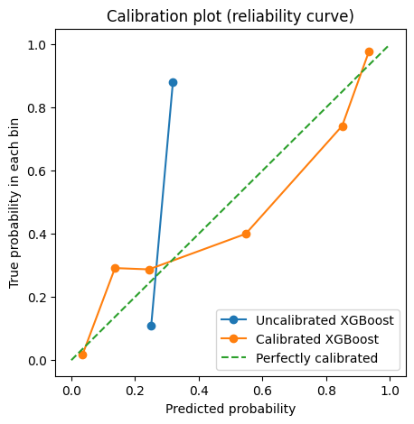

```python
import matplotlib.pyplot as plt
from sklearn.calibration import calibration_curve

# Get the predicted probabilities for the validation data from the uncalibrated model
y_prob_uncalibrated = model_xgb.predict_proba(X_test)[:, 1]

# Compute the calibration curve for the uncalibrated model
prob_true_uncalibrated, prob_pred_uncalibrated = calibration_curve(
    y_test,
    y_prob_uncalibrated,
    n_bins=10,
)

# Calibrate the model
if model_xgb.calibrate:
  model_xgb.calibrateModel(X, y, score="roc_auc")

# Predict on the validation set
y_test_pred = model_xgb.predict_proba(X_test)[:,1]


# Get the predicted probabilities for the validation data from calibrated model
y_prob_calibrated = model_xgb.predict_proba(X_test)[:, 1]

# Compute the calibration curve for the calibrated model
prob_true_calibrated, prob_pred_calibrated = calibration_curve(
  y_test,
  y_prob_calibrated,
  n_bins=10,
)


# Plot the calibration curves
plt.figure(figsize=(5, 5))
plt.plot(
  prob_pred_uncalibrated,
  prob_true_uncalibrated,
  marker="o",
  label="Uncalibrated XGBoost",
)
plt.plot(
  prob_pred_calibrated,
  prob_true_calibrated,
  marker="o",
  label="Calibrated XGBoost",
)
plt.plot(
  [0, 1],
  [0, 1],
  linestyle="--",
  label="Perfectly calibrated",
)
plt.xlabel("Predicted probability")
plt.ylabel("True probability in each bin")
plt.title("Calibration plot (reliability curve)")
plt.legend()
plt.show()
```

```python
print(model_xgb.classification_report)
```

```
              precision    recall  f1-score   support

           0       0.91      0.94      0.92       324
           1       0.79      0.71      0.75       104

    accuracy                           0.88       428
   macro avg       0.85      0.82      0.84       428
weighted avg       0.88      0.88      0.88       428
```

## Reference

El-Sadr, W., & Abrams, D. (1998). *AIDS Clinical Trials Group Study 175*. UCI Machine Learning Repository.  
https://doi.org/10.24432/C5G896.